# 36-315 Homework 10, Fall 2021

SOLUTIONS

Due Tuesday, November 16, 2021 (11:59pm ET) on Gradescope

# Homework 10: Time Series and Final Project EDA

## Problem 1: EDA for Final Project (10pts)

For this problem, all you need to do is turn in one plot using the dataset your team chose for the final project. The plot can be any visual of your choice, but it must meet these three requirements:

- At a minimum your graph must display three variables. (It can even display more, if you prefer.)
- Be sure that your plot is appropriately titled and labeled such that it is clear what you are plotting.
- Your graph should answer a question about your dataset that’s unique among your teammates. Thus, all your teammates shouldn’t make the same graph (or a graph of the same variables), and each of your graphs should answer a different question for the dataset. Thus, you’ll need to discuss with your team about the plots you all plan to make (and more generally, how you will divide up the work for your final project). This is exactly why we did not have lab on Friday, November 12 (so that you have more time to meet with your team and discuss).

```r
# PUT YOUR CODE AND PLOT HERE
```

After you’ve made your plot, interpret the plot in 2-4 sentences and discuss why you think this plot is informative for the kind of questions you want to answer with your dataset.

**[PUT YOUR ANSWER HERE]**

The best way to complete this question is to take a few days to think about your dataset (possiby discussing with your teammates) and make a few plots that you think are interesting, and then only submit your best plot for this question. You **should not** just try to make an arbitrary multivariate graph as quickly as possible to complete this problem, because if we think your graph/interpretation is not well-motivated given the goals of your project, we may deduct up to 7.5pts for this problem. After this homework, you should share your graph with your team, so you don’t want to make a graph that you’d be embarrassed to show your teammates.

## Problem 2: Data Manipulation to Create Basic Time Series Plots (28 points)

In this homework, we’ll use data from the [NYC Citi Bike](https://www.citibikenyc.com/) program. The NYC Citi Bike data is a tremendous resource; see [this page](https://www.citibikenyc.com/system-data) for details about the various datasets that are available. There are tons of data that we could work with here, and we’re just going to work with a small subset. To ensure that no one has issues accessing very large raw data files, I already subsetted the data for you, such that you can load it here:

```r
#loading the data
bikeData <- read.csv("https://raw.githubusercontent.com/zjbranson/315Fall2021/main/bikeData.csv")
```

1. (8pts) This dataset contains information about bike trips taken by individuals in New York City. The dataset contains time and geographic information (and we’re going to focus on the time information). But before we dive into that, let’s understand the demographics of the individuals in our dataset. There are three variables in the dataset related to demographics: `usertype`, `birth.year`, and `gender`. First, create a graph that you think best visualizes all three of these variables in a single graph. (Note: Using facets still counts as one graph.)

*We decided to use a facetted stacked histogram to visualize `usertype`, `birthYear`, and `gender`. (Note that, for `gender`, 0 = Unknown, 1 = Male, and 2 = Female.)*

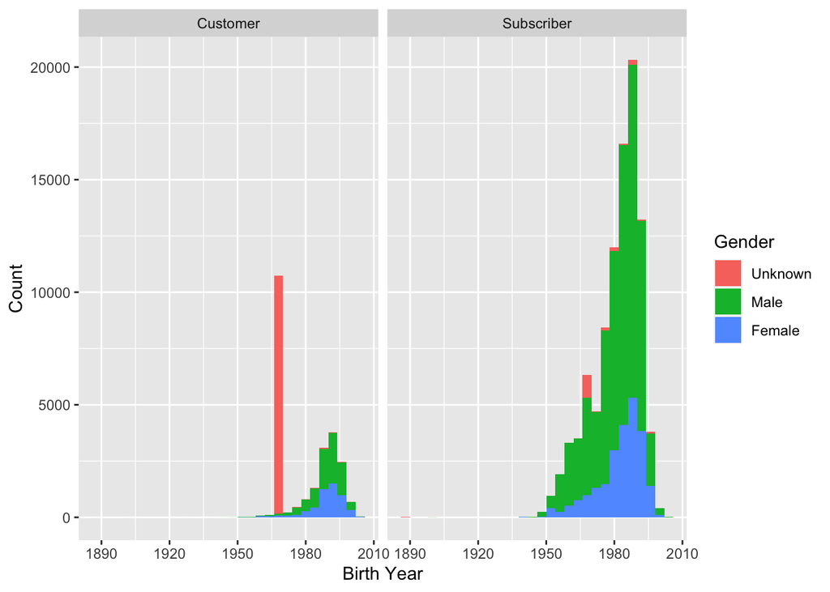

```r
library(ggplot2)
ggplot(bikeData, aes(x = birth.year, fill = factor(gender))) + geom_histogram() +
facet_grid(. ~ usertype) +
labs(x = "Birth Year", y = "Count") +
scale_fill_discrete(name = "Gender", labels = c("Unknown", "Male", "Female"))
```

After you’ve made your graph, answer the following two questions:

- In 1-3 sentences, use this graph to describe the subjects in this dataset in terms of `usertype`, `birth.year`, and `gender`. Note that you’ll need to read the data documentation above to understand how the `gender` variable is coded.

*We can see that the majority of subjects are categorized as “Subscriber” and not “Customer”. Furthermore, there are very few people whose gender is categorized as “Unknown”, at least among subscribers. Interestingly, there is a large number of customers with an unknown gender who all have the same age; we’ll discuss this in the next question. Meanwhile, for both subscribers and customers, the distribution of `birth year` is slightly left skewed, with the mode around 1985-1990; furthermore, it doesn’t look like this distribution is that different between different males and females. Interestingly, if you squint at the subscriber facet, you can see a handful of observations with a birth year before 1900; presumably these people listed their age as a joke, but let me know if you see any 120+ year old people cycling around.*

- Based on your visualization, are there any aspects about the data that seem strange? State Yes or No, and explain in one sentence. If you say Yes, give a 1-2 sentence explanation as to why this strange phenomenon might be occurring in this dataset.

*Yes - something that stands out in the visualization is the very large spike of customers who have an unknown gender. Upon further inspection, we can find that there is a very large number of customers wtih an unknown gender who all have a birth year of 1969:*

```r
table(subset(bikeData, usertype == "Customer")$birth.year)
```

```
##
##  1889  1904  1930  1942  1946  1948  1949  1950  1951  1952  1953  1954  1956
##     1     1     1     1     2     1     1     2     1     2     1     8     3
##  1957  1958  1959  1960  1961  1962  1963  1964  1965  1966  1967  1968  1969
##     8    16    27    18    14    29    13    28    21    39    24    44 10591
##  1970  1971  1972  1973  1974  1975  1976  1977  1978  1979  1980  1981  1982
##    73    52    46    45    85    88    99   145   119   124   211   198   258
##  1983  1984  1985  1986  1987  1988  1989  1990  1991  1992  1993  1994  1995
##   243   345   346   377   494   648   832  1107  1014   966   961   837   781
##  1996  1997  1998  1999  2000  2001  2002  2003  2004
##   695   612   379   214   243   138    91    34     4
```

*I’m guessing that this occurred because whenever a customer did not provide any information to the Citi Bike program, the system set their birth year to 1969 by default. There is actually a [quirky reason](https://www.mentalfloss.com/article/26316/why-does-my-gadget-say-its-december-31-1969) why 1969 or 1970 is the default year for many systems, and so you may see this phenomenon quite often when working with datasets that collect data on many users.*

(For most data analyses - including the final project - it is often useful to first visualize the types of subjects that are in your dataset before immediately diving into nuanced analyses about complex information like time and location data. So, this question is meant to give you some more practice with that.)

2. (10pts) Now we will explore time-varying aspects of the data. The variable `start.date` contains the day that someone began a bike trip. To utilize this variable, we first need to convert it to a `Date` variable. (By default, `start.date` is likely classified as a `character` variable.) The following code does this for you:

```r
#  convert start.date variable to Date
library(tidyverse)
bikeData <- mutate(bikeData, start.date = as.Date(start.date, format ="%m/%d/%y"))
```

(Note that I had to use `%m/%d/%y` - instead of `%m/%d/%Y` used in the Lecture 20 `R` demo - because the date in `bikeData` is recorded with a *two-digit* year instead of a four-digit year. At first I thought about being sinister and asking you to figure out the format yourself, but I decided to save you some time.)

Now, for this part, create a new `data.frame` called `trips_per_day` that contains two columns:

- `start.date`: All of the unique dates in `start.date` in the `bikeData` dataset.
- `n_trips`: The number of trips that were made on each particular `start.date`.

For example, the following code shows you that 58 trips were made on January 1, 2019:

```r
sum(bikeData$start.date == "2019-01-01")
```

```
## [1] 58
```

So, one of the rows of the dataset should have `start.date = "2019-01-01"` and `n_trips = 58`.

**Hint**: Use the `group_by()` and `summarize()` functions, which we’ve used a lot in this class.

*Here is how you can create the `trips_per_day` dataset (which counts the number of bike rides per day):*

```r
trips_per_day <- bikeData %>%
  group_by(start.date) %>%
  summarize(n_trips = n())
```

Now, using the dataset you created, plot the number of trips over time. Do this using `ggplot()` and `geom_line()`, with `n_trips` on the y-axis and `start.date` on the x-axis. Be sure the plot is appropriately titled and labeled.

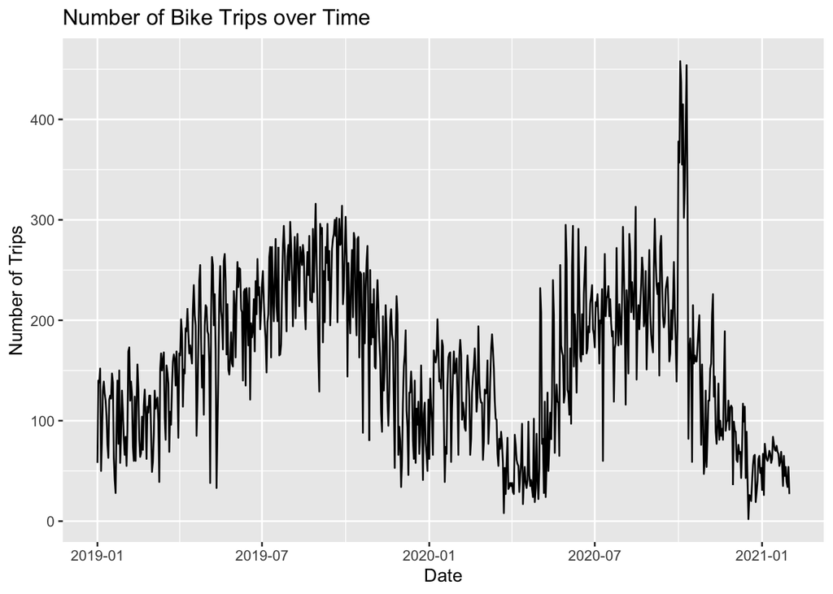

```r
ggplot(trips_per_day, aes(x = start.date, y = n_trips)) + geom_line() + labs(x = "Date", y = "Number of Trips", title = "Number of Bike Trips over Time")
```

After you do this, describe the plot in 1-3 sentences, particularly in terms of global trends and seasonality.

*We see that there is a clear seasonality trend, where number of trips peaks during the summer and valleys during the winter (which is intuitive - not many people are going to ride bikes in the winter). However, we can note that there is a slight uptick in rides in January 2020; I’m curious if this was due to New Year’s resolutions or something similar (a similar small uptick happens in January 2021). Meanwhile, we can note that the trends in 2019 and 2020 are fairly similar; perhaps this is notable in that 2019 is a “pre-pandemic” year and 2020 is a “pandemic” year. Finally, it’s worth noting that there is an unusually large spike in rides around October 1, 2020 (I’m not sure why this is the case).*

3. (10pts) Now let’s think back to the dataset you created in Part B. Each row should contain a day and the number of trips made on that day. But some of those trips were made by `usertype = "Customer"`, and some were made by `usertype = "Subscriber"`.

For this part, create a new dataset that breaks down `trips_per_day` (which you created in Part B) by `usertype`. Call this dataset `trips_per_day_usertype`. For example, the following code demonstrates that, among trips made on January 1, 2019, 7 were “customers” and 51 were “subscribers”.

```r
table( subset(bikeData, start.date == "2019-01-01")$usertype )
```

```
##
##   Customer Subscriber
##          7         51
```

Thus, one row of the `trips_per_day_usertype` dataset should have `start.date = "2019-01-01"`, `usertype = "Customer"`, and `n_trips = 7` and another row should have `start.date = "2019-01-01"`, `usertype = "Subscriber"`, and `n_trips = 51`.

**Hint**: Part B essentially asked you to `group_by()` the variable `start.date`. In this part, you need to `group_by()` `start.date` *and* `usertype`.

```r
trips_per_day_usertype <- bikeData %>%
  group_by(start.date, usertype) %>%
  summarize(n_trips = n())
```

After you’ve done this, using `trips_per_day_usertype`, create the same time series plot as Part B, but colored by `usertype`. In other words, your plot should show two time series: one for “customers” and one for “subscribers.” When making your plot, set `alpha` to something less than 1 so you can more easily see both time series.

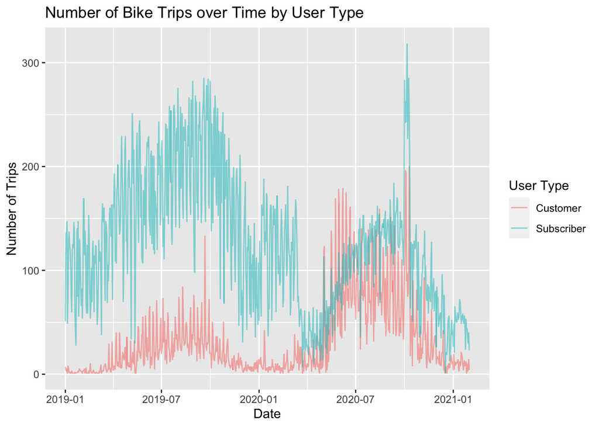

```r
ggplot(trips_per_day_usertype, aes(x = start.date, y = n_trips)) +
geom_line(data = trips_per_day_usertype, aes(color = usertype), alpha = 0.5) + labs(x = "Date", y = "Number of Trips", color = "User Type", title = "Number of Bike Trips over Time by User Type")
```

After you’ve made your plot, compare and contrast the two time series in your plot in 1-3 sentences.

*Both time series (for customers and subscribers) have a similar seasonality trend, where there are a high number of trips in the summer and a low number of trips in the winter. Also, in 2019-2021, it appears that there tends to be more trips by subscribers than customers. However, interestingly, in 2020, it seems like the number of trips gneerally increased for customers but decreased for subscribers, compared to 2019. As a result, there seem to be substantially more trips made by subscribers than customers in 2019, but only slightly more in 2020.*

## Problem 3: Lags and Autocorrelation (20 points)

1. (8pts) In this problem we will explore autocorrelations, which are just the correlation of a time series with itself at different lags. Before making autocorrelation plots for the NYC bike data, let’s start by looking at a totally random, made up time series:

```r
rand_ts <- rnorm(1000)
```

This is just 1000 random numbers from a Normal(0, 1) distribution; thus, this is simulating a time series at 1000 time points.

Using the `acf()` function, create an autocorrelation plot of `rand_ts`. The `acf()` function by default computes the autocorrelation for lags 0 through 30. (In general, this default value will depend on the length of the time series.) **When making your autocorrelation plot for this question**, display the autocorrelation for lags 0 through 500 instead. (**Hint**: Check the help documentation for `acf` to see how to change the maximum lag calculated.)

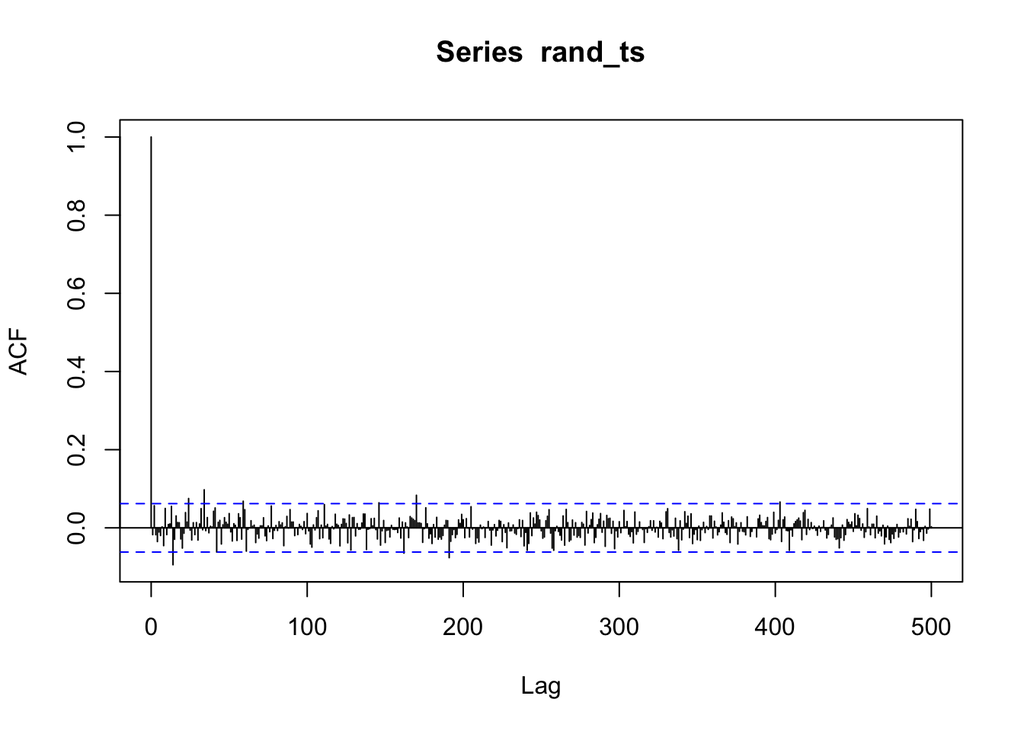

```r
acf(rand_ts, plot = TRUE, lag.max = 500)
```

After you’ve made the plot, answer the following questions:

- According to the confidence intervals in your plot, are any of the autocorrelations significantly different from zero? If so, which lags appear to have autocorrelations significantly different from 0?

*Obviously the autocorrelation for lag = 0 is outside the confidence interval. Meanwhile, we see that there are a few random autocorrelations outside of the confidence interval.*

- If you conclude that some of the autocorrelations are significantly different from 0, give an explanation why some autocorrelations are significantly different from zero. In particular, some lags beyond lag = 0 may appear significantly different from zero; discuss why this is the case, especially considering that `rand_ts` is by definition a totally random time series.

*The autocorrelation for lag = 0 being outside the confidence interval is totally expected: the correlation of a time series with itself will always be 1. Meanwhile, we see that there are a few random autocorrelations outside of the confidence interval. This is also totally expected: In fact, we should expect around 5% of the autocorrelations to be outside the confidence interval, because in this case we know the null hypothesis of no autocorrelation is true. This is a callback to Stat 101 material (i.e., what a confidence interval is). So, whenever you’re looking at confidence intervals across long periods of time (as in the plot above), you should take any particular observation outside the confidence interval with a grain of salt.*

2. (6pts) Now make an autocorrelation plot for the NYC bike data using `trips_per_day$n_trips` (which you should have defined in Problem 2). In particular, make two plots: One with the default lags 0 through 30, and another plot with lags 0 through 500. When making your plots, please display them in a 1 x 2 grid by using `par(mfrow = c(1,2))` before your two `acf()` lines of code.

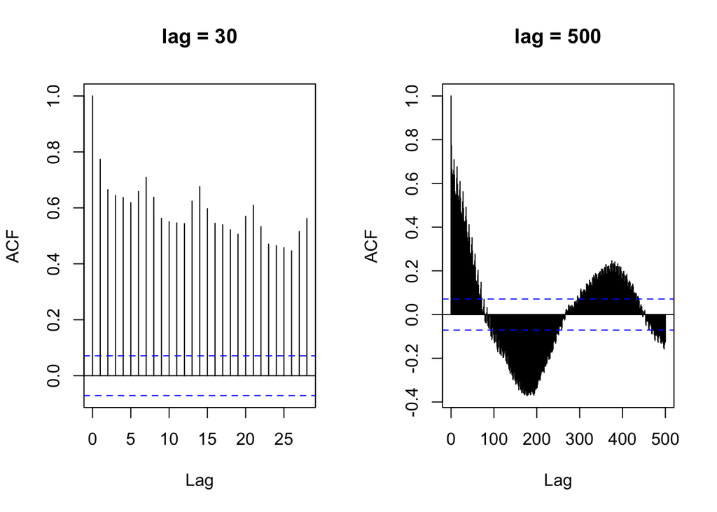

```r
par(mfrow = c(1,2))
acf(trips_per_day$n_trips, plot = TRUE, main = "lag = 30")
acf(trips_per_day$n_trips, plot = TRUE, lag.max = 500, main = "lag = 500")
```

After you’ve made your plots, interpret them in 1-3 sentences. Be sure to interpret your plots within the context of this dataset, which is about bike rides.

*In the left-hand plot, we see that there is very high positive correlation amongst all of the lags; we can also see a slight oscillation, probably due to a weekly seasonality trend (e.g., people may ride bikes more frequently on weekends). Meanwhile, in the right-hand plot, we see a distinct seasonality trend (likely denoting the summer-winter seasonal trend we noted in Problem 2). The point of this problem was to demonstrate that it can often be helpful to make multiple autocorrelation plots. Making the maximum lag small allows us to see local trends (like weekly seasonality), but it may also be misleading (e.g., if we only made the left-hand plot, we may think that there is only positive autocorrelation); meanwhile, making the maximum lag large allows us to see global trends, and it’s also much easier to detect where there are positive and negative correlations. Both plots provide valuable information.*

3. (6pts) Now, using `trips_per_day_usertype` (which you should have defined in Problem 2), create two autocorrelation plots of the `trips_per_day_usertype` time series, one for subscribers and one for customers. For both plots, display lags 0 through 500, and again arrange the plots in a 1 x 2 grid. Furthermore, when you make your plots, note that the axes for both plots are on different scales, which makes it more difficult to compare the plots; to make the axes the same, use `ylim = c(-0.3, 1)` within the `acf()` function.

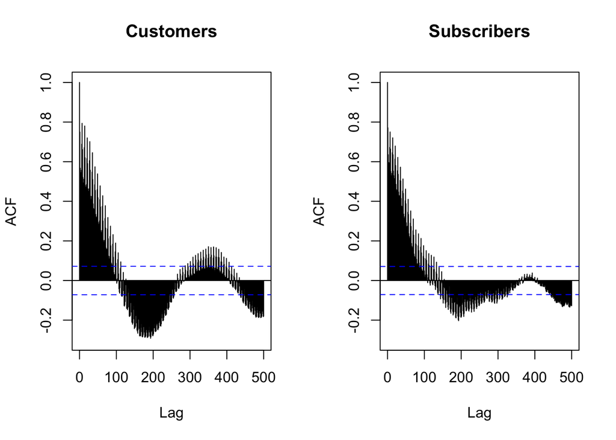

```r
par(mfrow = c(1,2))
acf(subset(trips_per_day_usertype, usertype == "Customer")$n_trips, plot = TRUE, lag.max = 500,
    ylim = c(-0.3, 1), main = "Customers")
acf(subset(trips_per_day_usertype, usertype == "Subscriber")$n_trips, plot = TRUE, lag.max = 500,
    ylim = c(-0.3, 1), main = "Subscribers")
```

After you’ve made your plots, compare and contrast them in 1-3 sentences. Again, be sure to interpret your plots within the context of this dataset.

*There are clearly seasonality trends for both groups (customers and subscribers), and they seem to peak and valley at similar times. Perhaps the most noticeable thing is that, for subscribers, the second valley is much longer/wider and the second peak is much shorter and smaller than that for customers. This is likely due to the fact that there is, for subscribers, an unusual increase in the number of trips in January-February of 2020 (as seen at the end of Problem 2), as well as the much smaller peak in the summer of 2020. In short, the time series for subscribers is less predictable than that for customers (at least in 2020), thereby leading to weaker autocorrelations.*

## Problem 4: Moving Averages (26 points)

Now we’ll visualize moving averages for the NYC bike dataset.

1. (8pts) Make a moving average plot for the `trips_per_day` dataset. You’ll need to install (and load) the `ggseas` library to do this. Your plot should use the functions `ggplot()`, `geom_line()`, and `stat_rollapplyr()`. Be sure that the output from `geom_line()` and `stat_rollapplyr()` are different colors so that the plot is easier to read. Furthermore, within `stat_rollapplyr()`, set `align = "left"`, and choose a `width` that you think makes the most sense for this dataset. In particular, choose a `width` that fits the data well and is interpretable for this dataset. (**Hint**: The measurements for this dataset are made on a daily basis. In the Lecture 20 `R` Demo, I chose `width = 12` because we were working with monthly measurements, and thus `width = 12` corresponded to a years’ worth of data. Meanwhile, `width = 12` doesn’t have as much meaning for the NYC Citi Bike dataset.)

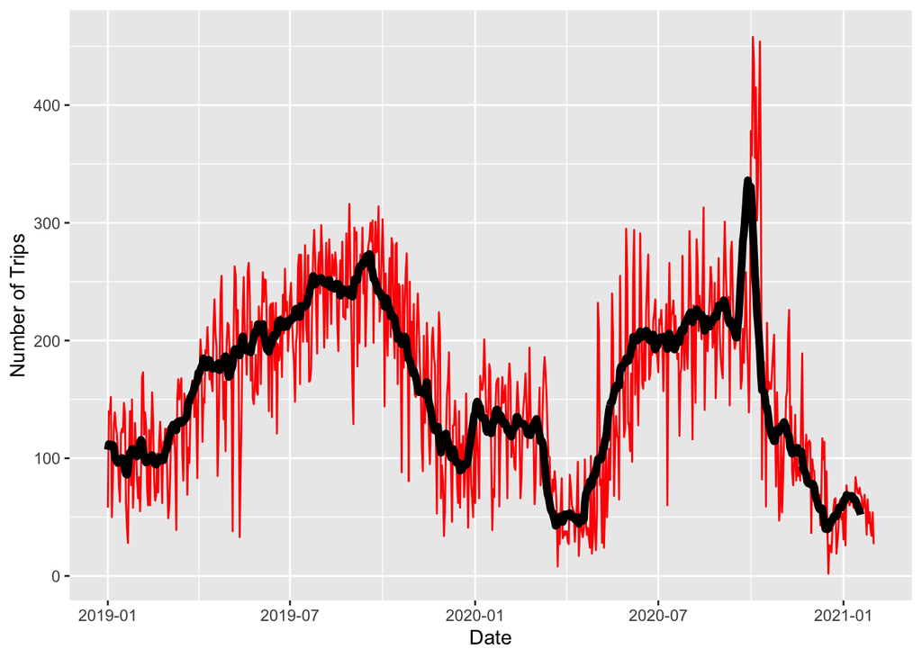

```r
library(ggseas)
ggplot(trips_per_day, aes(start.date, n_trips)) + geom_line(color="red") +
  stat_rollapplyr(width = 14, align = "left", size = 2) +
  labs(x = "Date", y = "Number of Trips")
```

After you’ve made your plot, discuss in 1-2 sentences why you chose this particular `width` value for your plot. (Don’t worry describing the moving average plot; just discuss the `width` value you chose.)

*We picked `width = 14` because it seems to result in a curve that fits the data well (albeit a bit wiggly); furthermore, it has the interpretation of averaging across two-weeks’ worth of data. One could also increase `width` slightly to get a slightly smoother curve, but we found that increasing `width` too much led to a curve that did not fit the data very well.*

2. (8pts) Repeat Part A (i.e., copy-and-paste your plot code here), and then make the following changes:
- Make two moving average lines, one for `usertype = Customer` and one for `usertype = Subscriber`, with different colors. This will require you to use the `trips_per_day_usertype` dataset instead of the `trips_per_day` dataset, as well as ensure that the lines are colored by `usertype`.
- In your plot, only display the moving average lines and **not** the raw time series lines. In other words: Part A displayed both the raw time series line and the moving average line; your plot should instead display just the two moving average lines, one for each `usertype`.

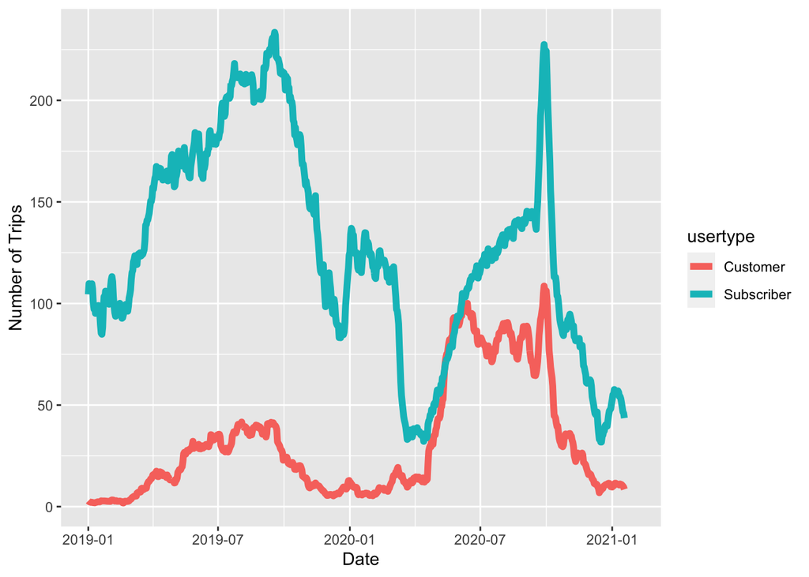

```r
ggplot(trips_per_day_usertype, aes(start.date, n_trips, color = usertype)) +
  stat_rollapplyr(width = 14, align = "left", size = 2) +
  labs(x = "Date", y = "Number of Trips")
```

3. (10pts) There is a whole literature on different moving averages; for example, we discussed weighted moving averages and cumulative moving averages in class. In this problem, we’ll work with a special kind of weighted moving average that’s commonly used in finance: an [exponential moving average](https://en.wikipedia.org/wiki/Moving_average#Exponential_moving_average) (EMA).

The idea of EMAs is to upweigh recent time periods and downweigh far away time periods when computing the moving average. In this part, you must compute the EMA in the `trips_per_day` dataset (i.e., ignoring `usertype`), and then plot that EMA on top of the raw time series. An EMA is defined in the following way:

- For the first time period, $t = 1$, set $S_1 = Y_1$, where $S_t$ is the EMA at time point $t$, and $Y_t$ is the outcome at time point $t$ (in our case, `n_trips`).
- For the next time periods ($t > 1$), define $S_t = \alpha Y_t + (1- \alpha) S_{t-1}$ for some constant $\alpha$. Typically, people set $\alpha = 2/(h + 1)$, where $h$ is the size of the window (i.e., the `width` you specified in Part A).

Luckily, `trips_per_day` should already be ordered by `start.date`, which will make computing the EMA easier. Below is some template code to get you started with computing the EMA; you must alter this code, based on the above methodology for computing the EMA:

```r
#first, define EMA in the dataset
trips_per_day$ema = vector(length = nrow(trips_per_day))
#initialize the first EMA
trips_per_day$ema[1] = trips_per_day$n_trips[1]

#define alpha
alpha = 2/(14 + 1)
#define the remaining EMAs
for(i in 2:nrow(trips_per_day)){
  trips_per_day$ema[i] = alpha*trips_per_day$n_trips[i] +
    (1-alpha)*trips_per_day$ema[i-1]
}
```

*Note that, in the above code, we defined $\alpha = \frac{2}{14 + 1}$, because we set `width = 14` in Parts A and B. Then, within the for loop, we used the equation given in the second bullet point above.*

After you’ve altered the above code such that `ema` is defined, create a plot with `n_trips` on the y-axis and `start.date` on the x-axis (similar to Problem 2B), as well as a line denoting the EMA. When making your plot, be sure that the raw time series and EMA are different colors.

*Note that, when making our plot below, we made two calls to `geom_line()`, such that we could display the raw time series in black using just `geom_line()` as well as the moving average in red.*

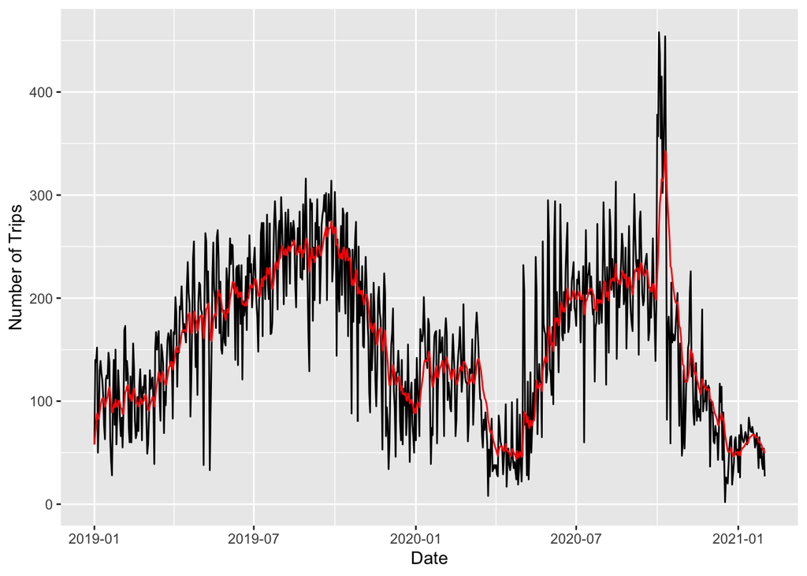

```r
ggplot(trips_per_day, aes(x = start.date, y = n_trips)) +
geom_line() + geom_line(aes(x = start.date, y = ema), color = "red") + labs(x = "Date", y = "Number of Trips")
```

For this part, all you have to do is create the plot. You should end up with a moving average that looks similar to the kind of moving averages you might see for stock prices.

## Problem 5: Seasonal Decompositions (16 points)

1. (8pts) Using the `ggsdc()` function in the `ggseas` library, create a seasonal decomposition plot for `trips_per_day`. Within the `ggsdc` function, there are two arguments, `frequency` and `s.window`. The `frequency` argument is basically the same as the `width` argument in the `stat_rollapplyr()` function, so set `frequency` equal to the value you set `width` to in Problem 4. Meanwhile, set `s.window = 7`. (Thinking more deeply about what to set `s.window` to is outside the scope of this class, but I encourage final project teams working with time series data to think about it.)

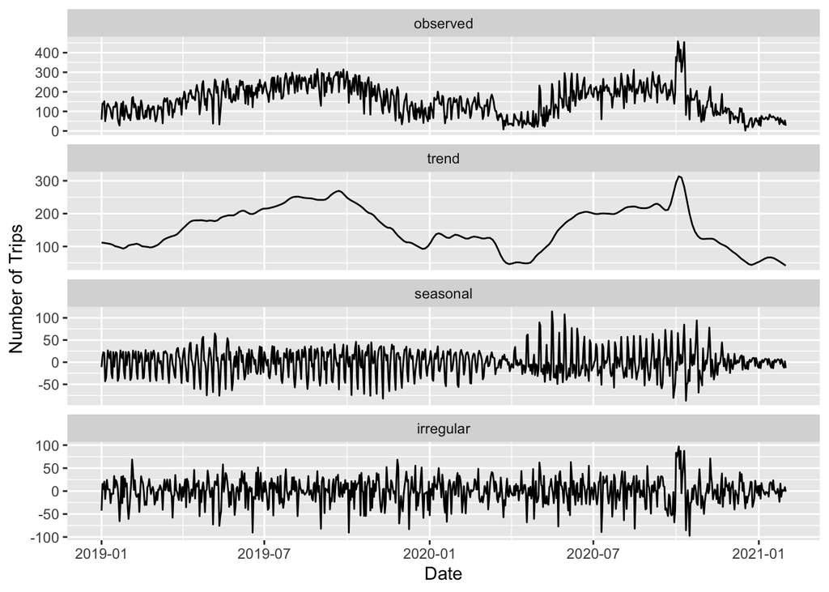

```r
ggsdc(trips_per_day, aes(start.date, n_trips),
    frequency = 14, method = "stl", s.window = 7) + geom_line() +
  labs(x = "Date", y = "Number of Trips")
```

After you’ve made your plot, interpret it in 1-4 sentences. In particular, be sure to discuss each of the four plots provided by the `ggsdc()` function.

*We already saw and discussed the top plot in Problem 2B, so we won’t discuss it further. Meanwhile, the “trend” plot shows the same characteristics we noted in our moving average plots and several other plots: There are distinct increases in trips during the summer and decreases during the winter, but with that unusual increase in early 2020. Meanwhile, the “seasonal” plot appears to be picking up the small weekly oscillations that we noted in Problem 3B. Meanwhile, there does not appear to be any clear trend in the “irregular” plot.*

2. (8pts) Now make a seasonal decomposition plot for `trips_per_day_usertype` with lines colored by `usertype`. Within `geom_line()`, set `alpha` equal to something less than 1 to make it easier to see all the lines. If you’ve made your plot successfully, the top plot should basically be the same plot you made in Problem 2C, and the second plot should basically be the same plot you made in Problem 4B. Meanwhile, the last two plots provide additional information you haven’t seen yet.

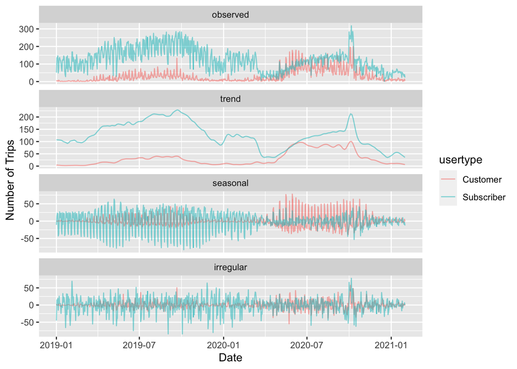

```r
ggsdc(trips_per_day_usertype, aes(start.date, n_trips, color = usertype),
    frequency = 14, method = "stl", s.window = 7) + geom_line(alpha = 0.5) + labs(x = "Date", y = "Number of Trips")
```

After you’ve made your plot, interpret the last two plots in the seasonal decomposition plot in 1-3 sentences.

*As discussed in the homework problem, we already saw the top plot in Problem 2, and we (basically) already saw the “trend” plot in Problem 4. Thus, we will not discuss these plots further here. The most defining feature of the “seasonal” plot is that the “subscribers” trend exhibits much more variation than that of “customers” in 2019, but then the opposite holds for most of 2020; this is likely because there is a relaive decrease in the number of rides for subscribers in 2020 but a relative increase for customers, as we discussed at the end of Problem 2. Finally, there does not appear to be any clear trend in the “irregular” plot; we can at least note that there seems to be more variation for subscribers in 2019, but this is likely due to the larger number of subscriber rides (compared to customer rides) in 2019.*